None

# Table of Contents

Parts modified from [AeroPython: Infinite Row of Vortices](https://github.com/barbagroup/AeroPython/blob/master/lessons/05_Lesson05_InfiniteRowOfVortices.ipynb)

## Vortices

```python
import numpy as np
import matplotlib.pyplot as plt
```

### Single Vortex

A vortex is motion in circular streamlines. Imagine streamlines that are concentric circles about a given point—what's confusing at first is that this does not mean that fluid elements are themselves rotating!

In an irrotational vortex, the tangential velocity $v_\theta$ is constant along a (circular) streamline and inversely proportional to the radius, while the radial velocity $v_r$ is zero. In polar coordinates that reads:

\begin{equation} v_\theta\left(r,\theta\right) = \frac{\Gamma}{r} \\ v_r\left(r,\theta\right) = 0 \end{equation}

where $r$ denotes the radial distance to the center and $\Gamma$ the strength of the vortex.

A vortex can also be expressed by a complex value function: \begin{equation} \Phi = \frac{i \Gamma}{2\pi} \text{log}(z-z_0) \end{equation}

with $z_0$ denoting the center of the vortex. Note that the major functionality of $\Phi$ is given by the complex logarithm, like for the sinks and sources in potential flow. The imaginary unit $i$ as a a factor basically leads to a switch between real and imaginary parts of the following expression. Thus, while there is a singularity in the imaginary part for sources and sinks, the vortex has a singularity in the real part of the complex potential. Let's visualize the vortex of strength 1 around the origin using the 'contour' and 'streamplot' functions of the'matplotlib' library.

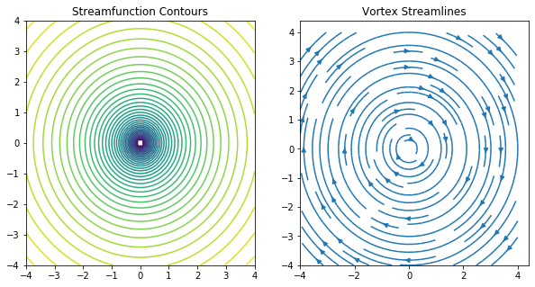

```python
fig = plt.figure(figsize=(10, 5))

def vortex(Z): return gamma*1j*np.log(Z-z0)/2/np.pi

z0 = 0; gamma = 1
x = np.linspace(-4,4,50); y = np.linspace(-4,4,50)
X,Y = np.meshgrid(x,y); Z = X + 1j*Y                         # complex mesh
Phi = vortex(Z)                                              # vortex

ax1 = fig.add_subplot(121)
ax1.contour(X,Y,np.imag(Phi),50)
ax1.set_title('Streamfunction Contours')

ax2 = fig.add_subplot(122)
[U,V] = np.gradient(np.imag(Phi))
ax2.streamplot(X,Y,U,-V)
ax2.set_title('Vortex Streamlines')
plt.show()
```

Note in the code that the 'streamplot' function uses the velocity that is computed from the streamfunction. In that way one avoids the problem with the branch cut in the real part of the complex vortex potential.

Let's visualize streamlines for a vortex combined with a sink using superposition!

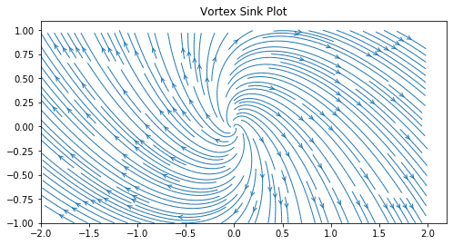

```python
fig, ax = plt.subplots(figsize=(8,8))

def source(Z): return -Q*np.log(Z-z0)/2/np.pi

z0 = 0; gamma = 1; Q = 1
x = np.linspace(-2,2,50); y = np.linspace(-1,1,50)
X,Y = np.meshgrid(x,y); Z = X + 1j*Y                                # complex mesh
Phi = vortex(Z)                                                     # vortex
[U1,V1] = np.gradient(np.imag(Phi))
Phi = source(Z)                                                     # source
[V2,U2] = np.gradient(np.real(Phi))

ax.streamplot(X, Y, U1-U2, -V1-V2, density=2, linewidth=1, arrowsize=1, arrowstyle='->')
ax.set_aspect('equal')
ax.set_title('Vortex Sink Plot')
plt.show()
```

For the source a function was defined, following the design that was applied for the other constructions of the complex potential.

One important note: the streamlines for the vortex are computed using the imaginary part of the complex potential (streamfunction), but for the sink they are derived from the real part. This is important, in order to avoid the above mentioned problems with the branch cut of the complex logarithm.

### Magnus Effect

An interesting application of the vortex potential is the flow around a rotating sphere, also called a spinning sphere. The complex potential consists of three terms. The first term describes uniform flow with an asympoptotic velocity $Q_0$. The combination of uniform flow with a dipole was already tackled before. Adding a vortex makes the sphere spin.

\begin{equation} \Phi = Q_0 (z-z_0) + \frac{Q_0 r_0^2}{z-z_0} - \frac{i \Gamma}{2\pi}\text{log}(z-z_0) \end{equation}

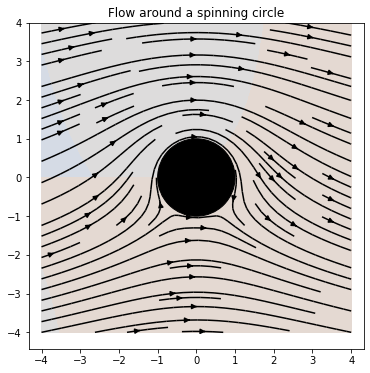

```python
fig, ax = plt.subplots(figsize=(6,6))

def base(Z): return -np.conj(Q0)*Z
def dipole(Z): return mu*np.exp(1j*alpha)/2/np.pi/(Z-z0)

xmin = -4; xmax = 4; ymin = -4; ymax = 4
z0 = 0 + 0*1j; alpha = 0; Q0 = 1; gamma = 10; r0 = 1
mu = 2*np.pi*Q0*r0*r0
x = np.linspace(xmin,xmax,1000); y = np.linspace(ymin,ymax,1000)
[X,Y] = np.meshgrid (x,y); Z = X+1j*Y                               # complex mesh
Phi = -base(Z) + dipole(Z) + vortex(Z)                              # base + dipole - vortex
[U,V] = np.gradient(np.imag(Phi))                                   # velocity components

plt.contourf (X,Y,np.real(Phi),40,cmap='coolwarm')
ax.streamplot(X,Y,U,-V,color='k')
ax.set_title('Flow around a spinning circle')
circle = plt.Circle((0,0),r0, color='k')
ax.add_patch(circle)
plt.axis('equal')
plt.show()
```

This simulates the so called **Magnus effect**, named after the German physicist Heinrich Gustav Magnus (1802-1870), who investigated it experimentally. The Magnus effect is used in ball sports, where the ball is taken a curved trajectory when it is given a spin.

The stagnation points $z_s$ fulfil the equation:

\begin{equation} -Q_0 - \frac{Q_0 r_0^2}{(z_s-z_0)^2} - \frac{i \Gamma}{2\pi(z_s-z_0)} = 0 \end{equation}

which can be rearranged to the quadratic equation

\begin{equation} (z_s-z_0)^2 + 2 i \gamma r_0 Q_0 (z_s-z_0) - a^2 = 0 \end{equation}

with $\gamma = \frac{\Gamma}{4 \pi Q_0 r_0}$. The roots of the equation are:

\begin{equation} z_s = -r_0 (i \gamma \pm \sqrt{1-\gamma^2}) \end{equation}

Let's compute and show them in the figure!

```python
Gamma = gamma/4/np.pi/Q0/r0; s = np.sqrt(1-Gamma*Gamma)
print (Gamma)
zs1 = -r0*(1j*Gamma+s); zs2 = -r0*(1j*Gamma-s)
```

```
0.7957747154594768
```

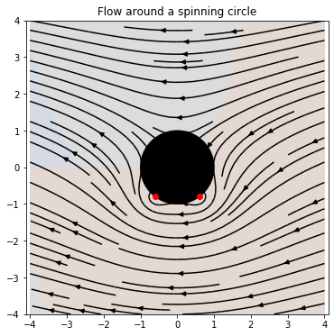

```python
fig, ax = plt.subplots(figsize=(6,6))
plt.contourf (X,Y,np.real(Phi),40,cmap='coolwarm')
ax.streamplot(X,Y,-U,-V,color='k')
ax.set_title('Flow around a spinning circle')
circle = plt.Circle((0,0),r0, color='k')
plt.plot(np.real(zs1),np.imag(zs1),'ro'); plt.plot(np.real(zs2),np.imag(zs2),'ro')
ax.add_patch(circle)
plt.axis('equal')
plt.show()
```

**Task 1**: Change the vortex strength! How does the flow pattern change, when the vortex strength increases and decreases? Show that the stagnation points coalence for $\gamma$=1.

### Row of Vortices

Consider the situation sketch in the figure below: a row of equally spaced vortices along the $x$-axis. Consider a line of $N$ vortices with a distance 0.4 apart from each other and equal strength $\Gamma$=1. Visualise using the 'streamplot' function in a domain including the 11 centered vortices. Vary the number of vortices!

[figure not shown]

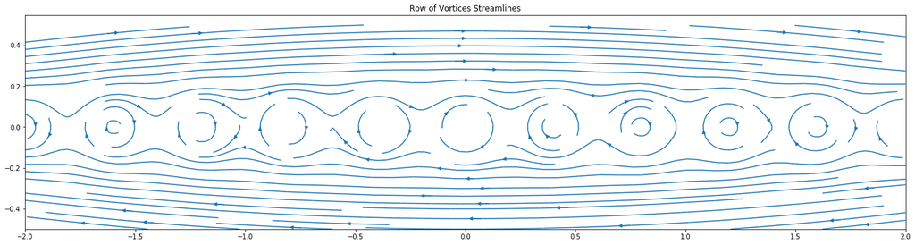

```python
fig, ax = plt.subplots(figsize=(24, 6))
x = np.linspace(-2,2,100); y = np.linspace(-0.5,0.5,50)
X,Y = np.meshgrid(x,y); Z = X + 1j*Y                              # complex mesh
Phi = 0.*Z
a = 0.4; N = 100
for i in range(N+1):
    Phi = Phi + 1j*np.log(Z-N/5+a*i)/2/np.pi                      # summation of vortices
[U,V] = np.gradient(np.imag(Phi))                                 # velocity components

ax.streamplot(X,Y,U,-V)
ax.set_title('Row of Vortices Streamlines')
plt.show()
```

The figure above shows the streamlines for N=100. If the vortex filaments all rotate clockwise, then the tangential velocity immediately above AB is to the right, while that immediately below AB is to the left. Thus, a discontinuity of tangential velocity exists across a vortex sheet. If the vortex filaments are not infinitesimally thin, then the vortex sheet has a finite thickness, and the velocity change is spread out.

### Infinite Row of Vortices

According to the principle of superposition, the complex potential representing an infinite row of vortices (on the line $y=0$) is given by

$$\Phi = \frac{i\Gamma}{2\pi}\sum_{m=-\infty}^{+\infty} \ln \left( z-ma \right)$$

Let's add the constant

$$ -\frac{i\Gamma}{2\pi} \sum_{m=-\infty, m\neq 0}^{+\infty} \ln \left( -ma \right)$$

so that, the complex potential can be cast in the following form

$$\Phi = \frac{i\Gamma}{2\pi}\sum_{m=-\infty,m\neq 0}^{+\infty} \ln \left( \frac{z-ma}{-ma} \right) + \frac{i\Gamma}{2\pi}\ln z$$

Now, it is time do some mathematics...

$$\Phi = \frac{i\Gamma}{2\pi}\sum_{m=-\infty,m\neq 0}^{+\infty} \ln \left( 1-\frac{z}{ma} \right) + \frac{i\Gamma}{2\pi}\ln z$$$$\Phi = \frac{i\Gamma}{2\pi}\sum_{m=1}^{+\infty} \left\lbrace \ln\left(1-\frac{z}{ma}\right) + \ln\left(1+\frac{z}{ma}\right) \right\rbrace + \frac{i\Gamma}{2\pi}\ln z$$$$\Phi = \frac{i\Gamma}{2\pi}\sum_{m=1}^{+\infty} \ln\left(1-\frac{z^2}{m^2a^2}\right) + \frac{i\Gamma}{2\pi}\ln z$$$$\Phi = \frac{i\Gamma}{2\pi} \ln\left(\prod_{m=1}^{+\infty}\left(1-\frac{z^2}{m^2a^2}\right)\right) + \frac{i\Gamma}{2\pi}\ln z$$$$\Phi = \frac{i\Gamma}{2\pi} \ln\left(z\prod_{m=1}^{+\infty}\left(1-\frac{z^2}{m^2a^2}\right)\right)$$$$\Phi = \frac{i\Gamma}{2\pi} \ln\left(z\prod_{m=1}^{+\infty}\left(1-\frac{\left(\frac{z\pi}{a}\right)^2}{m^2\pi^2}\right)\right)$$

The product is actually the formula for the sine and the complex potential becomes

$$\Phi = \frac{i\Gamma}{2\pi}\ln\left(\sin\left(\frac{z\pi}{a}\right)\right)$$

Let's visualize this with a plot of streamlines.

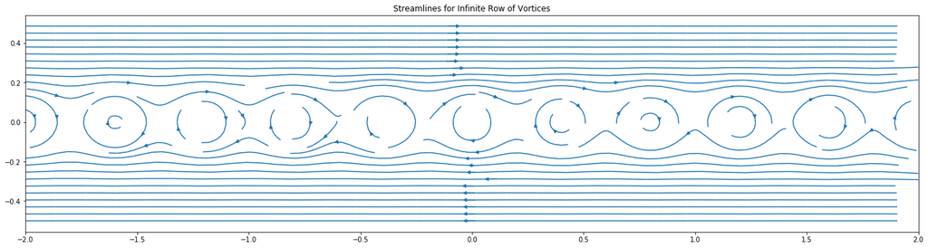

```python
fig, ax = plt.subplots(figsize=(24, 6))
Phi = 1j*np.log(np.sin(Z*np.pi/a))/2/np.pi
[U,V] = np.gradient(np.imag(Phi))
ax.streamplot(X,Y,U,-V)
ax.set_title('Streamlines for Infinite Row of Vortices')
plt.show()
```

Can you notice the differences with the previous case where the number of vortices was finite?

Play around with your plotting settings for the *finite* row of vortices, until you can get a plot that looks more like the infinite case. When can you say the finite case is a good approximation of the infinite case?

Notice that the streamline pattern is parallel to the *vortex sheet*: there is no net normal flow. Therefore, the sheet can model a solid surface in potential flow. We end up with a slip velocity at such an interface.

The line vortex is a vortex of constant strength Γ acting along the entire length of the line describing its path through space (Carlton 2018). With regard to vortex filaments Helmholtz, the German mathematician, physicist and physician (1821-1894), established some basic principles of inviscid vortex behavior, which have generally become known as Helmholtz’s vortex theorems:

- The strength of a vortex filament is constant along its length.
- A vortex filament cannot end in a fluid. Consequently, the vortex must extend to the boundaries of the fluid, which could be at ±∞ or, alternatively, the vortex filament must form a closed path within the fluid.

These theorems are particularly important since they govern the formation and structure of inviscid vortex propeller models.

### Boundary Conditions

**Task 2**: Visualize the flow of a vortex near a closed boundary, using an infinite row of vortices.

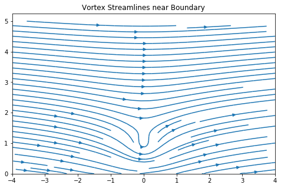

```python
fig, ax = plt.subplots(figsize=(8, 5))
z0 = 1j; gamma = 10; a = .1
x = np.linspace(-4,4,200); y = np.linspace(0,5,200)
X,Y = np.meshgrid(x,y); Z = X + 1j*Y                              # complex mesh
Phi = 1j*(-gamma*np.log(Z-z0)+np.log(np.sin(Z*np.pi/a)))/2/np.pi

[U,V] = np.gradient(np.imag(Phi))
ax.streamplot(X,Y,U,-V)
ax.set_title('Vortex Streamlines near Boundary')
plt.show()
```

**Task 3**: Visualize the flow of a vortex near a closed boundary, using the method of mirror images.

Hint: The complex function below places the closed boundary on the real axis.

$$\Phi = \frac{i\Gamma}{2\pi} \left (\ln (z-i z_0) - \ln (z+i z_0) \right) = \frac{i\Gamma}{2\pi} \ln \frac {z-i z_0}{z+i z_0} $$

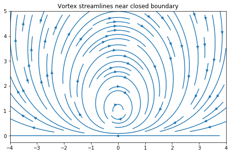

```python
fig, ax = plt.subplots(figsize=(8, 5))
z0 = 1j; gamma = 1
x = np.linspace(-4,4,200); y = np.linspace(0,5,200)
X,Y = np.meshgrid(x,y); Z = X + 1j*Y                              # complex mesh
Phi = gamma*1j*(np.log(Z-z0)-np.log(Z+z0))/2/np.pi                # potential for two vortices
[U,V] = np.gradient(np.imag(Phi))                                 # velocity components

ax.streamplot(X,Y,U,-V)
ax.set_title('Vortex streamlines near closed boundary')
plt.show()
```

**Task 4**: Add a baseflow component in horizontal direction!

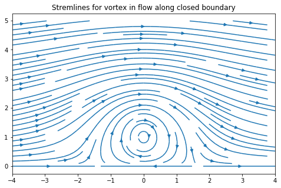

```python
fig, ax = plt.subplots(figsize=(8, 5))
z0 = 1j; gamma = 1; Q0 = .1
x = np.linspace(-4,4,200); y = np.linspace(0,5,200)
X,Y = np.meshgrid(x,y); Z = X + 1j*Y                              # complex mesh
Phi = Q0*Z+gamma*1j*(np.log(Z-z0)-np.log(Z+z0))/2/np.pi          # complex potential
[U,V] = np.gradient(np.imag(Phi))                                 # velocity components

ax.streamplot(X,Y,U,-V)
ax.set_title('Stremlines for vortex in flow along closed boundary')
plt.show()
```

**Task 5**: Change rotation!